# Exercises

DataBrew

## Friday

### Weather

1. Read in some Mozambican weather data by running the following

```r
library(tidyverse)
weather <- read_csv("https://github.com/databrew/maputo/blob/master/day3/data/mozambican_weather.csv?raw=true")
```

2. Take a look at the top of the data.
3. Create an object called `x`. This will be the `weather` data, then summarized to tell us the minimum and maximum dates.
4. Create an object called `y`. This will be the `weather` data, then summarized to tell us the maximum `temp_max` and the mimimum `temp_min`.
5. Create an object called `z`. This will be the `weather` data, but filtered to only include the year 2014 and only the district of “MATOLA”.
6. Make a plot of `z` with the `date` on the x-axis and the average temperature (`temp`) on the y-axis.
7. Make a plot of `z` showing the distribution of precipitation.
8. Make a plot showing the distribution of the maximum temperature, but faceted by district.
9. Color the lines in the above red.
10. Add another distribution the above chart with the minimum temperature. Color it blue. To do this you will need to add another `geom_density` line to your chart, and you can include another `aes()` section within that `geom_density` function.

### Time data

1. Load up some data about the weight of chickens over time. Create an object called `frangos`.

```r
data('ChickWeight')
frangos <- ChickWeight
```

2 How many columns does the data have?

3 How many rows does the data have?

4 What are the variable types (quantitative/numeric or categorical)?

5 Create a point chart showing weight on the x-axis and time on the y-axis.

6 Create an object called `frango1`. This should be just the data for chicken number 1 (ie, 1 in the `Chick` column).

7 Chart the weight of chicken 1 over time using `geom_point()`

8 Chart the weight of chicken 1 over time using `geom_line()`

9 Chart the weight of chicken 1 over time using `geom_area()`

10 Chart the weight of *all* chickens over time using `geom_line()`. Make the color of each line different for each chicken.

11 Create an object called `zero`. This should be the frangos only at day 0 (ie, when they are born).

12 Make a histogram of chicken’s weights at day 0.

13 Make a density plot of chicken’s weights at day 0.

14 Make a violin plot of chicken’s weights at day 0. On the x-axis, put the `Diet` type. On the y-axis, put the weight.

15 Add points to the violin plot

### Switzerland

1. Load up data on health and sociodemographic factors from Switzerland.

```r
library(tidyverse)
data('swiss')
swiss <- swiss
```

2. Look at the `cabeça` of the data. Describe it.
3. Make a chart showing the association between Agriculture rate and Fertility rate. This should be a scatterplot. You’ll use `geom_point`.
4. Describe the association.
5. Add the argument `geom_smooth()` to the above chart. What happens?
6. Run the following code to create a variable called `canton` from the `row.names` of the data:

```r
swiss$canton <- row.names(swiss)
```

7. Create an object called `x`. This will be the `swiss` data, but only keeping those cantons which are more than 80% catholic.
8. How many rows are in `x`?
9. Go back to your `swiss` data. Is there an association between `Education` and `Catholicism`? Show it in a chart.
10. Create a variable a new variable in `swiss` called `edu`, which indicates whether the canton is highly-educated (at or above the average) or has low education (below the average). Here’s the code to do this:

```r
swiss <- swiss %>%
  mutate(edu = ifelse(Education >= mean(Education),
                      "High education",
                      "Low education"))
```

11. Create a variable in `swiss` called `fert`. This variable should show whether the canton has high fertility or low fertility. Use the code in the previous question as a guide.
12. Create an object called `y`. This will be the `swiss` data, grouped by both your new `edu` and `fert` variables, and then summarized to tell the average infant mortality rate for each subgroup.
13. Make a barplot of the data in y. Add the argument `position = 'dodge` to within `geom_bar()` to make the bars not stack
14. Interpret the above chart. Which group has the highest infant mortality? Which one has the lowest?
15. Arrange the data by infant mortality. Which canton has the lowest?
16. What is the maximum infant mortality for all Swiss canons?
17. What is the maximum infant mortality for canons with high education?
18. What is the average infant mortality for canons with high fertility.
19. Make a plot showing the relationship between fertility (on the x-axis) and infant mortality (on the y-axis).
20. Add `color = edu` to within the `aes()` section of the above chart.
21. Make a “density” plot of fertility.
22. Create a new variable in `swiss` using `mutate`. The new variable will be named `ag`. This should be whether a canton is very agricultural or not (ie, more than 50%). To do this:

```r
swiss <- swiss %>%
  mutate(ag = ifelse(Agriculture > 50, 'Very agricultural',
                     'Not very agricultural'))
```

23. Create an overlapping density chart of infant mortality in which the `fill` shows whether a place is very agricultural or not.
24. Create a new variable in your data called `cath`. This should whether or not a canton is very Catholic (ie, > 50%).
25. Create an overlapping density chart of fertility in which the `fill` is whether a place is very Catholic or not.
26. Use `ggridges` to create a ridgeline chart of the distribution of infant mortality by your `cath` variable (here’s the code to help)

```r
library(ggridges)
ggplot(data = swiss,
       aes(x = Infant.Mortality,
           y = cath)) +
  ggridges::geom_density_ridges()
```

27. Create a ridgeline chart (like above) showing fertility instead of infant mortality.
28. Which areas have more children: Catholic or non-Catholic areas?
29. Use the `cut` function to generate a 4-category categorical variable of the `Education` variable. Call this new variable `educat`. Note that `cut` takes two arguments: first, the variable you are cutting; second, the number of categories you want.
30. Make a ridgeline plot of infant mortality’s distribution by your new `educat` variable.
31. Can you create the following plot? You’ll need to add `facet_wrap(~educat)`…

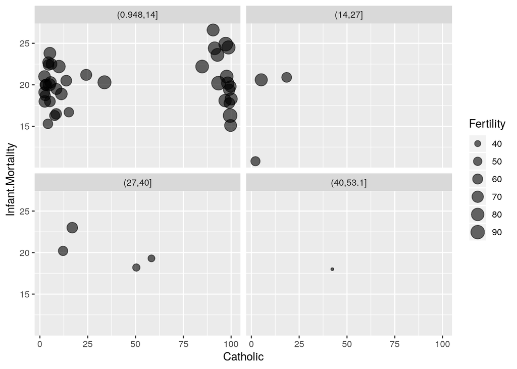

```r
ggplot(data = swiss,
       aes(x = Catholic,
           y = Infant.Mortality,
           size = Fertility)) +
  facet_wrap(~educat) +
  geom_point(alpha = 0.6)
```

32. What percentage of high-Catholicism cantons are agricultural?
33. What percentage of low fertility canons are Catholic?

### Markdown

1. Install these packages if you don’t yet have them

```
knitr
rmarkdown
DT
```

2. In the upper left of RStudio, click “File”, then “New File”, then “R Markdown”.
3. Name your file: “Mapping with R”
4. In your new file, run CTRL + s in order to save. Save it as “mapping” (for example).
5. Delete lines 11 until the end.
6. Write the following in order to create a “header” section:

```
## How to get data
```

7. Move your cursor below that section, and then click on “Insert” at the top of the code window. From there, click on “R”.
8. You now have a section for writing R code. In that section, write:

```r
library(raster)
library(leaflet)
library(tidyverse)
```

9. Click “Knit” in the top of the window in order to compile the document.
10. Now add more text and R sections to create a complete guide for mapping in R.

### Regression

1. Load up data on health and sociodemographic factors from Switzerland.

```r
library(tidyverse)
data('swiss')
swiss <- swiss
```

2. Create an object called `fit`. This will be a regression where the outcome variable is `Infant.Mortality`, and the predictor variables are `Catholic` and `Agriculture`
3. What is the association between catholicism and infant mortality? Is it significant?
4. What is the association between fertility and infant mortality? Is it significant?
5. Create an object called `ci`. This will be the confidence intervals for each of our regression terms.

```r
ci <- confint(fit)
```

6. Make both `fit` and `ci` into a better format for plotting.

```r
library(broom)
tidyfit <- tidy(fit)
tidyci <- data.frame(ci)
```

7. Combine them using `cbind`.

```r
combined <- cbind(tidyfit, tidyci)
```

8. Make a barchart of the estimates.
9. Use `geom_hline(yintercept = 0)` to add a line at 0.
10. Use `geom_errorbar` to add error bars to your plot.
11. Advanced: Create a binary variable and run logistic regression to predict its likelihood.
12. Advanced: Create a regression with at least 3 predictor variables. Use `sjPlot::tab_model()` to tabulate it.

### Cities

1. Read in some data on the location of cities from the internet.

```r
cities <- read_csv(url("https://github.com/databrew/maputo/raw/master/day4/data/simplemaps-worldcities-basic.csv"))
```

2. Create a chart showing the distribution of population of the cities
3. Create a simple scatter plot of the longitude and latitude
4. Create an object called `x`. This will be the number of cities in each country.
5. Create an object called `mozambique`. This will only be cities in Mozambique.
6. Create an object called `sa`. This will only be cities in South Africa.
7. Plot `mozambique`.
8. Plot `sa`.
9. Combine `mozambique` and `sa` into one object using `rbind`. Call this new object `combined`
10. Plot combined, with the point color reflecting the country.
11. Create an overlapping density chart of the populations of the cities of South Africa vs. Mozambique (use `combined`).
12. Create a leaflet map of all the world’s cities.
13. Create a leaflet map of the cities in `combined`.
14. Create a leaflet map of all the world’s cities, but only those with a population of more than 100000.